# Dynamic Models for Poisson, Binomial and Multinomial Time Series

Gregor Zens

## Introduction

`DynCount` fits Bayesian state-space models to count time series. A latent trajectory $z_t$ evolves with one of two dynamics,
$$z_t = \mu + \rho\, z_{t-1} + \varepsilon_t,$$
a first-order random walk (`latent_dynamics = "rw"`, i.e. $\rho = 1$) or a stationary AR(1) process (`latent_dynamics = "ar1"`, with $\rho$ estimated and constrained to $(-1, 1)$). The scalar $\mu$ is zero unless it is switched on with `include_mu = TRUE`. Under the random walk it acts as a drift, and under AR(1) it is an intercept that is always included. The observations are linked to the latent trajectory through one of three observation models:

- **Poisson** with a log link, so that $y_t \sim \mathrm{Poisson}(e^{z_t})$;
- **Binomial** with a logit link, so that $y_t \sim \mathrm{Binomial}(m_t,\, \mathrm{logit}^{-1}(z_t))$, where the trials $m_t$ are known;
- **Multinomial**, for choice counts over $K$ categories with known totals $N_t$. Here each non-baseline category $k$ has its own latent additive-log-ratio series $z_{t,k} = \log(p_{t,k}/p_{t,b})$, which gives $K - 1$ latent processes (see below).

An optional known `offset` $o_t$ may be added to the linear predictor of all three observation models. It acts as a log-exposure for the Poisson mean, $e^{o_t + z_t}$, as a shift of the binomial logit, and as a per-category shift of the multinomial log-ratios. It is a fixed, user-supplied input, not part of the latent process $z_t$, and defaults to zero.

The distribution of the increments $\varepsilon_t = z_t - \mu - \rho z_{t-1}$ is controlled by the `innovations` argument. It can be Gaussian (`"gaussian"`, the default), Student-t (`"t"`), a finite scale mixture of normals (`"mixture"`) or a stochastic volatility process (`"sv"`, which requires the stochvol package). For the Poisson and binomial families, zeros can be handled by zero inflation with a time-constant gate-open probability (`zeros = "inflated"`) or treated as missing values (`zeros = "missing"`).

The model is estimated by Metropolis-within-Gibbs MCMC. The latent states are updated with adaptive random-walk Metropolis steps that use their Gaussian Markov random field full conditionals. The innovation parameters, $\mu$ and $\rho$ are drawn by Gibbs steps, with a Metropolis step for the Student-t degrees of freedom. Forecasts are obtained after fitting by forward simulation from the posterior draws.

The package implements and extends the methodology of Zens and Bijak (2026), *The Annals of Applied Statistics*, [doi:10.1214/26-AOAS2171](https://doi.org/10.1214/26-AOAS2171).

Note that the MCMC runs below use short chains (`nsave` = 1000, `nburn` = 1000) and, for the two shipped series, a shortened window, so that the vignette builds quickly. The effective number of draws can be much smaller than `nsave`. For real analyses, use longer chains and the full series, and check convergence as shown in the section on convergence below.

## Simulating data

The simulation helpers generate data with a known latent path, which is useful for checking recovery. `simulate_dynamic_poisson()` returns the counts `y`, the latent log-rate `log_rate` and the Poisson mean `rate`.

```r
sim <- simulate_dynamic_poisson(n = 80, sigma = 0.18, log_rate0 = 2.5, seed = 1)
str(sim, max.level = 1)
```

```
#> List of 5
#>  $ y         : num [1:80] 10 15 13 9 7 12 15 11 19 18 ...
#>  $ log_rate  : num [1:80] 2.5 2.39 2.42 2.27 2.56 ...
#>  $ rate      : num [1:80] 12.18 10.88 11.25 9.68 12.9 ...
#>  $ offset    : num [1:80] 0 0 0 0 0 0 0 0 0 0 ...
#>  $ structural: logi [1:80] FALSE FALSE FALSE FALSE FALSE FALSE ...
```

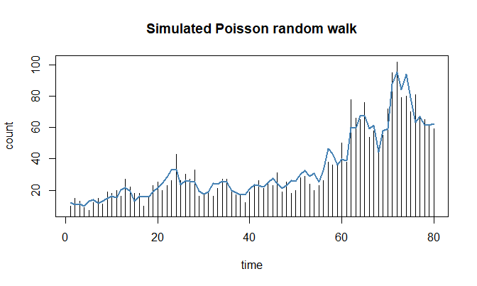

```r
plot(sim$y, type = "h", xlab = "time", ylab = "count",
     main = "Simulated Poisson random walk")
lines(sim$rate, col = "steelblue", lwd = 2)
```

## Fitting a Poisson model

The main entry point is `fit_dynamic_model()`. The defaults give an ordinary Poisson random walk with Gaussian increments.

```r
fit <- fit_dynamic_model(sim$y, family = "poisson",
                         nsave = NSAVE, nburn = NBURN, seed = 1)
fit
```

```
#> <dynamic_fit>
#>   family      : poisson
#>   dynamics    : rw  (rho = 1)
#>   innovations : gaussian
#>   zeros       : none
#>   observations: 80  (zeros: 0)
#>   draws kept  : 1000
```

```r
summary(fit)
```

```
#> Dynamic count model summary
#>   family = poisson | dynamics = rw | innovations = gaussian | zeros = none
#>   80 observations (0 zeros), 1000 posterior draws
#>
#> Global parameters (posterior summaries):
#>            mean     sd   q2.5    q50  q97.5
#> innov_sd 0.1528 0.0243 0.1082 0.1517 0.2049
#>
#> Fitted values: range of posterior means [10.94, 93.31]
```

For this model the only global parameter is `innov_sd`, the standard deviation of the latent increments. Its true value in the simulation is 0.18. `plot_fitted()` overlays the posterior of the fitted mean on the data, and `plot_latent()` shows the latent log-rate trajectory with a credible band.

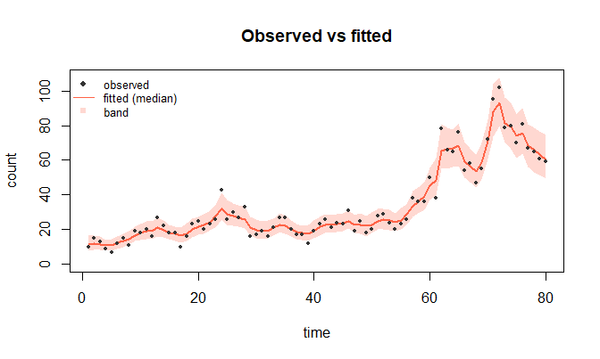

```r
plot_fitted(fit)
```

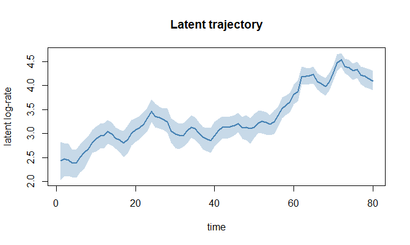

```r
plot_latent(fit)
```

`predict()` summarises the in-sample fit. With the default `type = "mean"` it returns the posterior of the mean of $y_t$, and with `type = "response"` it returns posterior predictive replicates of $y_t$.

```r
head(predict(fit)$summary)
```

```
#>   time observed     mean       sd     q2.5      q50    q97.5
#> 1    1       10 11.58507 2.344105 7.554892 11.42956 16.91972
#> 2    2       15 11.88528 2.122722 8.180216 11.73251 16.39812
#> 3    3       13 11.70898 2.002064 8.311704 11.46163 16.28356
#> 4    4        9 10.93698 1.614310 8.058833 10.84032 14.20784
#> 5    5        7 10.97079 1.680634 7.930762 10.94188 14.39572
#> 6    6       12 12.19498 1.775691 8.884296 12.24329 16.03465
```

The draws themselves are stored in `fit$draws`. Its main components are the latent states `z` (a draws x time matrix aligned with the observations), the increment variances `sig2`, the fitted means `fitted`, the replicates `yrep` and the parameter draws (`innov_var`, `rho`, `mu` and, depending on the model, `nu`, `pi_open`, `mix_weight`, `sv_phi` and others). The summary rows are derived from these draws. For example, `innov_sd` is the square root of `innov_var`, `t_df` summarises `nu`, `ar1_rho` summarises `rho`, `drift_mu` or `intercept_mu` summarise `mu`, and `gate_open_prob` summarises `pi_open`. The full layout is documented in `?fit_dynamic_model` and `?summary.dynamic_fit`.

## Forecasting

Forecasts are obtained by forward simulation. For every stored posterior draw, `forecast()` propagates the latent path from the last in-sample state with the state equation, drawing the increments from the fitted innovation structure. It then draws a response from the observation model at each simulated state, so the intervals reflect parameter, state and innovation uncertainty. Future states carry no likelihood, so this gives exact draws from the posterior predictive distribution, and the horizon can be chosen after fitting.

```r
fc <- forecast(fit, horizon = 8, seed = 1)
fc                                 # prints the forecast path
```

```
#> <dynamic_forecast> poisson, horizon 8
#>  horizon   mean       sd   q2.5 q50   q97.5
#>        1 60.900 14.68440 34.000  60  92.000
#>        2 62.308 18.27871 34.000  60 103.025
#>        3 63.368 21.93298 29.975  60 119.025
#>        4 63.852 24.56293 25.000  61 121.050
#>        5 64.182 25.88960 26.975  60 122.025
#>        6 64.804 28.14288 25.000  59 129.000
#>        7 65.320 29.99472 23.975  60 136.000
#>        8 66.302 31.62187 21.975  61 147.075
```

```r
fc$final                           # the single 8-step-ahead forecast
```

```
#>   horizon   mean       sd   q2.5 q50   q97.5
#> 1       8 66.302 31.62187 21.975  61 147.075
```

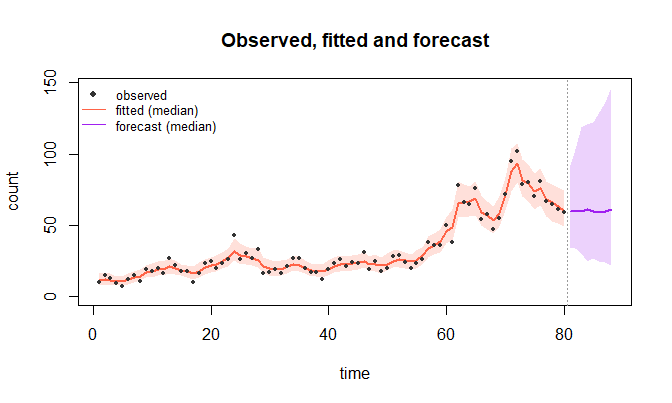

```r
plot_forecast(fit, horizon = 8, seed = 1)
```

The object stores the full forecast path (`fc$summary`, one row per horizon) and, separately, the final h-step-ahead prediction (`fc$final`, `fc$final_draws`). Alternatively, `fit_dynamic_model(..., horizon = H)` simulates an `H`-step forecast right after sampling and stores it in the fit, and `forecast(fit)` without a horizon then returns the stored forecast. If a fit holds no stored forecast, `forecast()` needs a `horizon` and stops with an error otherwise.

## AR(1) latent dynamics

Setting `latent_dynamics = "ar1"` estimates an autoregressive coefficient $\rho$ instead of fixing it at 1, jointly with an intercept $\mu$. The pair is drawn by an exact conjugate Gibbs step, with $\rho$ **truncated to the stationary region** $(-1, 1)$, so the posterior places mass only on stationary processes. **AR(1) always includes an intercept.** The package enables `include_mu` automatically, which gives the process a non-zero stationary mean $\mu / (1 - \rho)$. The random walk corresponds to $\rho = 1$, which lies outside the AR(1) parameter space, so the two specifications are separate models rather than nested ones.

```r
# a genuinely stationary AR(1) log-rate with stationary mean 4, so mu = 4 * (1 - rho)
sim_ar <- simulate_dynamic_poisson(n = 150, sigma = 0.2, log_rate0 = 4,
                                   rho = 0.9, mu = 0.4, seed = 3)
# no need to set include_mu, because AR(1) enables the intercept automatically
fit_ar <- fit_dynamic_model(sim_ar$y, family = "poisson", latent_dynamics = "ar1",
                            nsave = NSAVE, nburn = NBURN, seed = 3)
summary(fit_ar)                    # reports the posteriors of ar1_rho and intercept_mu
```

```
#> Dynamic count model summary
#>   family = poisson | dynamics = ar1 | innovations = gaussian | zeros = none
#>   150 observations (0 zeros), 1000 posterior draws
#>
#> Global parameters (posterior summaries):
#>                mean     sd   q2.5    q50  q97.5
#> innov_sd     0.1668 0.0185 0.1321 0.1659 0.2055
#> ar1_rho      0.9102 0.0392 0.8278 0.9126 0.9824
#> intercept_mu 0.3529 0.1561 0.0673 0.3418 0.6827
#>
#> Fitted values: range of posterior means [22.13, 119.22]
```

For a random walk with drift, keep the default dynamics and set `include_mu = TRUE`. The drift then appears as `drift_mu` in the summary.

## Offset

For Poisson data with varying exposure, pass a known `offset` (a log-exposure term), and the mean becomes $\exp(\text{offset}_t + z_t)$. When forecasting, supply the future exposures as `forecast_offset`, either one value per horizon or a single value that is recycled. If a model has an offset and no `forecast_offset` is given, `forecast()` warns and assumes an offset of zero.

```r
expo  <- log(runif(120, 50, 200))  # known exposure, e.g. population at risk
sim_o <- simulate_dynamic_poisson(n = 120, sigma = 0.12, log_rate0 = -3.5,
                                  offset = expo, seed = 4)
fit_o <- fit_dynamic_model(sim_o$y, family = "poisson", offset = expo,
                           nsave = NSAVE, nburn = NBURN, seed = 4)
forecast(fit_o, horizon = 6, forecast_offset = log(120), seed = 4)$final
```

```
#>   horizon   mean       sd q2.5 q50  q97.5
#> 1       6 13.659 7.099516    4  12 31.025
```

## Example data

The package ships two real weekly count series of irregular maritime crossings, which are loaded on first use. `uk_weekly` covers English Channel crossings from ISO week 2018-W01 to 2025-W11 (376 weeks), and `med_weekly` covers Mediterranean crossings from 2015-W40 to 2025-W11 (494 weeks). Both have the columns `week` (the ISO week label), `count` and `date` (the Monday of the week).

```r
str(uk_weekly)
```

```
#> 'data.frame':    376 obs. of  3 variables:
#>  $ week : chr  "2018-W01" "2018-W02" "2018-W03" "2018-W04" ...
#>  $ count: int  0 0 0 0 7 0 0 0 0 0 ...
#>  $ date : Date, format: "2018-01-01" "2018-01-08" ...
```

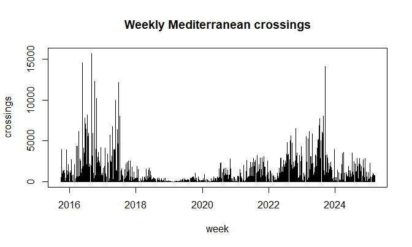

```r
plot(med_weekly$date, med_weekly$count, type = "h", xlab = "week",
     ylab = "crossings", main = "Weekly Mediterranean crossings")
```

## Heavy-tailed and time-varying innovations

The Mediterranean series has large counts and few zeros. With Gaussian increments, the occasional large week-to-week jump would inflate the innovation variance for the whole series. The Student-t innovation makes the latent path robust to such jumps. For a fast build we use the most recent 120 weeks.

```r
med <- tail(med_weekly$count, 120)
fit_med <- fit_dynamic_model(med, family = "poisson",
                             innovations = "t",
                             nsave = NSAVE, nburn = NBURN, seed = 2)
summary(fit_med)
```

```
#> Dynamic count model summary
#>   family = poisson | dynamics = rw | innovations = t | zeros = none
#>   120 observations (1 zeros), 1000 posterior draws
#>
#> Global parameters (posterior summaries):
#>            mean     sd   q2.5    q50   q97.5
#> innov_sd 1.5913 0.1556 1.3331 1.5792  1.9482
#> t_df     6.3387 3.3456 3.1800 5.3718 16.5819
#>
#> Fitted values: range of posterior means [1.87, 14109.57]
```

The posterior of the degrees-of-freedom parameter `t_df` indicates how heavy the increment tails are, with smaller values indicating heavier tails. Its prior is set with `df_min` and `df_mean_excess` in `dynamic_prior()`.

A finite scale mixture of normals is a more flexible alternative. The number of components is set with `dynamic_prior(mix_components = ...)` and defaults to two. The components are exchangeable and are not identified individually, so `summary()` reports only `innov_sd`, the marginal standard deviation of the increments. The draws of the component weights and variances are stored in `fit$draws$mix_weight` and `fit$draws$mix_var`.

```r
fit_mix <- fit_dynamic_model(med, family = "poisson", innovations = "mixture",
                             nsave = NSAVE, nburn = NBURN, seed = 2)
summary(fit_mix)
```

```
#> Dynamic count model summary
#>   family = poisson | dynamics = rw | innovations = mixture | zeros = none
#>   120 observations (1 zeros), 1000 posterior draws
#>
#> Global parameters (posterior summaries):
#>            mean     sd  q2.5   q50  q97.5
#> innov_sd 1.5355 0.1277 1.303 1.527 1.8136
#>
#> Fitted values: range of posterior means [2.76, 14126.63]
```

Stochastic volatility lets the increment variance change over time. The log-variance follows an AR(1) process whose level, persistence and volatility are reported as `sv_mu`, `sv_phi` and `sv_sigma`, and the per-increment variances are stored in `fit$draws$sig2`. This option requires the stochvol package.

```r
fit_sv <- fit_dynamic_model(med, family = "poisson", innovations = "sv",
                            nsave = NSAVE, nburn = NBURN, seed = 2)
summary(fit_sv)
```

```
#> Dynamic count model summary
#>   family = poisson | dynamics = rw | innovations = sv | zeros = none
#>   120 observations (1 zeros), 1000 posterior draws
#>
#> Global parameters (posterior summaries):
#>            mean     sd    q2.5    q50  q97.5
#> innov_sd 1.7272 0.2105  1.3921 1.7040 2.1899
#> sv_mu    0.2633 0.4821 -0.8404 0.2904 1.1359
#> sv_phi   0.7886 0.0928  0.5878 0.7974 0.9440
#> sv_sigma 0.8051 0.1565  0.5160 0.8056 1.1180
#>
#> Fitted values: range of posterior means [0.92, 14116.60]
```

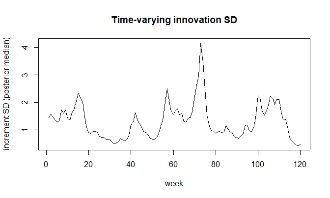

```r
vol <- sqrt(apply(fit_sv$draws$sig2, 2, median))
plot(vol, type = "l", xlab = "week", ylab = "increment SD (posterior median)",
     main = "Time-varying innovation SD")
```

## Checking convergence

MCMC output should be checked before it is interpreted. The effective sample size measures how many independent draws an autocorrelated chain is worth, and the coda package computes it directly from the stored draws.

```r
ess <- function(x) round(unname(coda::effectiveSize(x)))
c(innov_sd = ess(sqrt(fit$draws$innov_var)),
  z_40     = ess(fit$draws$z[, 40]),
  t_df     = ess(fit_med$draws$nu))
```

```
#> innov_sd     z_40     t_df
#>       63       96      122
```

With the short chains used here, several of these values are only a fraction of the 1000 kept draws. The innovation standard deviation of a smooth latent path is typically the slowest quantity to mix, so increase `nsave` (or `thin`) until the effective sample sizes of the quantities of interest are comfortably large. Trace plots, such as `plot(sqrt(fit$draws$innov_var), type = "l")`, and several chains with different seeds are useful further checks.

## Zero inflation and structural zeros

`uk_weekly` (English Channel crossings) has many zeros in its early weeks. Turning on zero inflation lets the model separate *structural* zeros from *sampling* zeros. A structural zero arises when a latent gate switches the count off, whereas a sampling zero is produced by the Poisson process itself. The gate is drawn separately for every week, while the probability that it is open is a single parameter that is constant over time. We use the zero-heavy early window of the series here.

```r
uk <- uk_weekly$count[1:130]
mean(uk == 0)                         # many zeros
```

```
#> [1] 0.4307692
```

```r
fit_zip <- fit_dynamic_model(uk, family = "poisson",
                             zero_inflation = TRUE,
                             nsave = NSAVE, nburn = NBURN, seed = 3)
summary(fit_zip)
```

```
#> Dynamic count model summary
#>   family = poisson | dynamics = rw | innovations = gaussian | zeros = inflated
#>   130 observations (56 zeros), 1000 posterior draws
#>
#> Global parameters (posterior summaries):
#>                  mean     sd   q2.5    q50  q97.5
#> innov_sd       0.9036 0.0960 0.7366 0.8910 1.1111
#> gate_open_prob 0.6985 0.0493 0.6006 0.6988 0.7890
#>
#> Fitted values: range of posterior means [0.09, 190.90]
```

In `fit_dynamic_model()`, `zero_inflation = TRUE` is shorthand for `zeros = "inflated"`. The summary row `gate_open_prob` is the posterior of the gate-open probability $\pi_{\text{open}}$, so one minus it is the probability of a structural zero. A simpler alternative is `zeros = "missing"`, which treats all observed zeros as missing values.

`structural_zero_prob()` reports, for each observed zero, the posterior probability that it is structural. By default it returns only the zero observations, and `zeros_only = FALSE` returns one row per observation. `plot_zero_inflation()` shows these probabilities as a bar chart with one bar per observed zero.

```r
sz <- structural_zero_prob(fit_zip)
head(sz, 10)
```

```
#>    time observed p_structural p_sampling
#> 1     1        0        0.484      0.516
#> 2     2        0        0.543      0.457
#> 3     3        0        0.563      0.437
#> 4     4        0        0.708      0.292
#> 5     6        0        0.671      0.329
#> 6     7        0        0.544      0.456
#> 7     8        0        0.439      0.561
#> 8     9        0        0.399      0.601
#> 9    10        0        0.381      0.619
#> 10   11        0        0.355      0.645
```

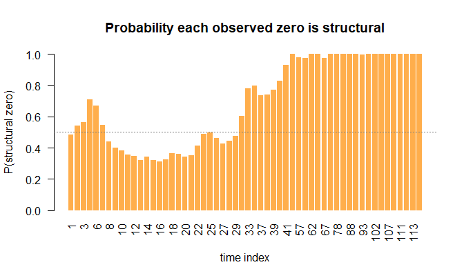

```r
plot_zero_inflation(fit_zip)
```

In the resulting table, a `p_structural` close to 1 flags a zero that the latent rate cannot easily explain (e.g., the underlying rate was high, so a Poisson zero would be unlikely). By contrast, a `p_structural` near 0 marks a zero that is consistent with a genuinely low rate.

### Conditional versus unconditional fits and replicates

Under zero inflation the observed count is $y_t = v_t \tilde y_t$, where the gate $v_t \sim \mathrm{Bernoulli}(\pi_{\text{open}})$ switches the count off and $\tilde y_t$ comes from the Poisson/binomial observation model. The fit stores **both** flavours of in-sample quantities:

- **Unconditional** quantities (`fitted`, `yrep`) include the gate and are the defaults returned by `predict()`. The replicates therefore reproduce the structural zeros, which makes them the right choice for **posterior predictive checks**.
- **Conditional on the gate being open**, the fit stores `fitted_open` and `yrep_open`, which `predict(fit, conditional = TRUE)` returns. These are the latent-implied mean and a replicate drawn straight from the observation model, so they describe the latent intensity process.

For models without zero inflation the two versions are identical. Response forecasts from `forecast()` are always unconditional, because the gate is applied to each forecast draw.

```r
# zero proportion in the data vs both flavours of replicate
c(observed      = mean(uk == 0),
  yrep          = mean(fit_zip$draws$yrep == 0),        # gate applied, so comparable
  yrep_open     = mean(fit_zip$draws$yrep_open == 0))   # gate open only, so too few zeros
```

```
#>  observed      yrep yrep_open
#> 0.4307692 0.4125077 0.1580692
```

## A binomial model with known trials

The binomial branch keeps the same interface, and the only addition is the known number of `trials`. A single value is recycled over time.

```r
simb <- simulate_dynamic_binomial(n = 80, sigma = 0.12, trials = 50, seed = 4)
fit_bin <- fit_dynamic_model(simb$y, family = "binomial", trials = simb$trials,
                             nsave = NSAVE, nburn = NBURN, seed = 4)
summary(fit_bin)
```

```
#> Dynamic count model summary
#>   family = binomial | dynamics = rw | innovations = gaussian | zeros = none
#>   80 observations (0 zeros), 1000 posterior draws
#>
#> Global parameters (posterior summaries):
#>            mean     sd   q2.5    q50  q97.5
#> innov_sd 0.1425 0.0295 0.0927 0.1411 0.1999
#>
#> Fitted values: range of posterior means [25.41, 42.83]
```

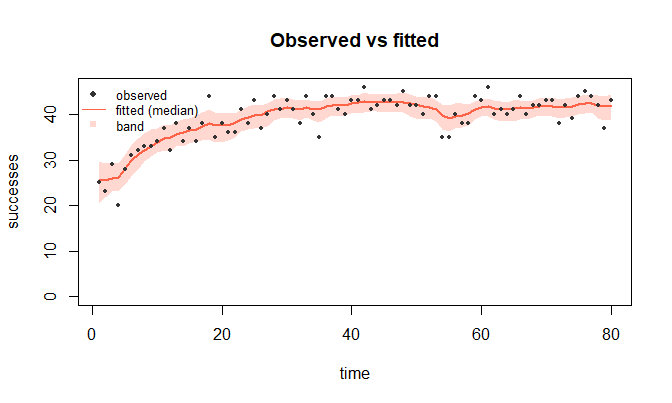

```r
plot_fitted(fit_bin)
```

Forecasting works the same way. Supply the future trial sizes as `forecast_trials`, either one value per horizon or a single value that is recycled. If they are omitted, the last observed number of trials is used.

```r
fc_bin <- forecast(fit_bin, horizon = 8, forecast_trials = 50, seed = 4)
fc_bin$summary
```

```
#>   horizon   mean       sd q2.5 q50 q97.5
#> 1       1 41.784 3.145033   35  42    47
#> 2       2 41.815 3.081277   35  42    47
#> 3       3 41.909 3.317789   35  42    48
#> 4       4 41.663 3.519064   34  42    47
#> 5       5 41.721 3.613061   34  42    48
#> 6       6 41.701 3.786018   33  42    48
#> 7       7 41.544 3.980441   33  42    48
#> 8       8 41.447 4.167560   32  42    48
```

Zero inflation is available for the binomial family too. Exactly as for the Poisson, a structural-zero gate sits in front of the `Binomial(m, p)` process. To use it, set `zero_inflation = TRUE` (or `zeros = "inflated"`) and read the per-zero diagnostics with `structural_zero_prob()`. Note that the simulators use their `zero_inflation` argument differently. In `simulate_dynamic_binomial()` it is the probability of a structural zero, here 0.2, which corresponds to a gate-open probability of 0.8.

```r
simz <- simulate_dynamic_binomial(n = 80, sigma = 0.1, trials = 40, logit0 = 1.5,
                                  zero_inflation = 0.2, seed = 7)
fit_bz <- fit_dynamic_model(simz$y, family = "binomial", trials = 40,
                            zero_inflation = TRUE,
                            nsave = NSAVE, nburn = NBURN, seed = 7)
summary(fit_bz)$params
```

```
#>                     mean         sd       q2.5       q50     q97.5
#> innov_sd       0.1481387 0.04418200 0.09874596 0.1375478 0.2849292
#> gate_open_prob 0.8037141 0.04375668 0.71258755 0.8058957 0.8815981
```

```r
head(structural_zero_prob(fit_bz))
```

```
#>   time observed p_structural p_sampling
#> 1    3        0            1          0
#> 2    4        0            1          0
#> 3   14        0            1          0
#> 4   19        0            1          0
#> 5   24        0            1          0
#> 6   43        0            1          0
```

## Multinomial choice counts

When each period yields counts over $K$ mutually exclusive categories, `family = "multinomial"` models the category *shares* dynamically. One category $b$ is the baseline – by default the one with the largest total count – and each of the remaining $K - 1$ categories has its own latent additive-log-ratio (ALR) series
$$z_{t,k} = \log \frac{p_{t,k}}{p_{t,b}}, \qquad
p_{t,k} = \frac{e^{z_{t,k}}}{1 + \sum_{j \ne b} e^{z_{t,j}}}, \qquad
y_t \sim \mathrm{Multinomial}(N_t, p_t),$$
where the row totals $N_t$ are treated as known. Every ALR series follows the selected `latent_dynamics` and `innovations`, but the series share no parameters. Instead, each has its own innovation variance, its own $\rho$ and $\mu$, and its own copy of the prior. The series therefore interact only through the multinomial likelihood, and the sampler updates each series in turn with the other categories held at their current values. Zero inflation is not available for this family, and rows with a total of zero are treated as missing.

The simulation below uses category C as the baseline. We pass the simulated baseline to the fit, so that the fitted log-ratios are on the same scale as the simulated ones. Without it the fit would use the default baseline, the category with the largest total count, which here is B.

```r
sim_m <- simulate_dynamic_multinomial(n = 80, sigma = c(0.15, 0.08), trials = 250,
                                      alr0 = c(-1, 0.3), baseline = 3,
                                      categories = c("A", "B", "C"), seed = 5)
head(sim_m$y)
```

```
#>       A   B   C
#> [1,] 39 132  79
#> [2,] 25 114 111
#> [3,] 48 118  84
#> [4,] 38 115  97
#> [5,] 28 118 104
#> [6,] 44 116  90
```

```r
colSums(sim_m$y)
```

```
#>     A     B     C
#>  3296 10081  6623
```

```r
fit_m <- fit_dynamic_model(sim_m$y, family = "multinomial",
                           baseline = sim_m$baseline,
                           nsave = NSAVE, nburn = NBURN, seed = 5)
fit_m
```

```
#> <dynamic_fit>
#>   family      : multinomial
#>   categories  : 3 (A, B, C); baseline = C
#>   dynamics    : rw  (rho = 1)
#>   innovations : gaussian
#>   zeros       : none
#>   observations: 80  (zero-total rows: 0)
#>   draws kept  : 1000
```

```r
summary(fit_m)$params
```

```
#>                   mean         sd       q2.5        q50     q97.5
#> innov_sd[A] 0.18505776 0.03156893 0.13277892 0.18227783 0.2603390
#> innov_sd[B] 0.07261848 0.01437368 0.05100505 0.07025055 0.1061444
```

The true innovation standard deviations are 0.15 for A and 0.08 for B. Posterior draws of multinomial fits carry a trailing category dimension. For example, `fit_m$draws$fitted_prob` is a `draws x time x K` array of shares, and the latent parameters (`innov_var`, `rho`, `mu`, …) are `draws x (K - 1)` matrices named by category. `predict()` and `forecast()` return long-format summaries with a `category` column, and the plot functions draw one panel per category. For forecasts, `forecast_trials` gives the future totals. If it is omitted, the last non-zero row total is used.

```r
head(predict(fit_m, type = "prob")$summary)
```

```
#>   time category observed      mean         sd      q2.5       q50     q97.5
#> 1    1        A    0.156 0.1436402 0.01792291 0.1082552 0.1426827 0.1778244
#> 2    2        A    0.100 0.1333023 0.01411823 0.1085621 0.1320271 0.1618523
#> 3    3        A    0.192 0.1592094 0.01606813 0.1297601 0.1588734 0.1903972
#> 4    4        A    0.152 0.1498739 0.01551025 0.1209839 0.1487282 0.1815924
#> 5    5        A    0.112 0.1396657 0.01538785 0.1092454 0.1401441 0.1690480
#> 6    6        A    0.176 0.1578097 0.01537631 0.1288524 0.1583275 0.1902902
```

```r
forecast(fit_m, horizon = 6, forecast_trials = 250, seed = 5)$final
```

```
#>   horizon category    mean       sd   q2.5 q50  q97.5
#> 1       6        A  32.117 15.42177  9.000  29  68.05
#> 2       6        B 134.882 17.32825 99.975 136 167.00
#> 3       6        C  83.001 12.78423 60.000  83 110.00
```

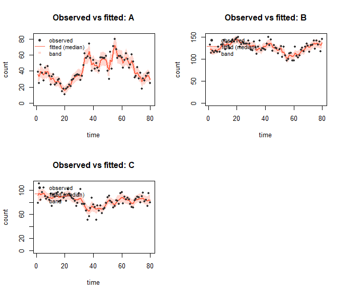

```r
plot_fitted(fit_m)
```

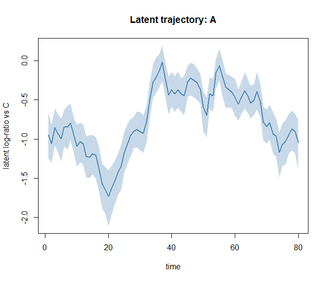

```r
plot_latent(fit_m, category = "A")
```

Two practical notes. First, the model is not invariant to the choice of baseline, because the dynamics are placed on the log-ratios *relative to the baseline*. If the baseline’s own share moves a lot, every ALR series inherits that movement. It is therefore best to choose a large category with a stable share (the `baseline` argument accepts a column name or index). Second, with $K = 2$ and the second column as baseline the model is exactly the binomial model of the previous section.

## Choosing and changing priors

Every prior hyperparameter is exposed through `dynamic_prior()`, and printing the object shows the current settings. The default prior on the innovation variance is $\mathrm{InvGamma}(0.01, 0.01)$. It is weakly informative for increment standard deviations of about 0.1 and above, but it is not scale-free. For very smooth series, with increment standard deviations of a few hundredths, the results can be sensitive to this prior, and a sensitivity check with a smaller `var_rate` is advisable. A larger `var_rate` favours rougher latent paths.

```r
dynamic_prior()
```

```
#> <dynamic_prior>
#>   innovation variance ~ InvGamma(shape = 0.01, rate = 0.01)
#>   t degrees of freedom = 3 + Exp(mean = 6)
#>   mixture: 2 components, Dirichlet concentration = 1,
#>            component variances ~ InvGamma(shape = 2.5, rate = 0.5)
#>   zero-inflation gate-open prob ~ Beta(1, 1)
#>   AR(1) rho ~ N(mean = 0, sd = 1) truncated to (-1, 1)  [ar1 only]
#>   drift/intercept mu ~ N(mean = 0, sd = 1)  [include_mu only]
#>   initial state ~ N(0, 100)  [rw and ar1]
#>   sv_prior: stochvol defaults
```

```r
# an informative prior favouring rougher latent paths
pr <- dynamic_prior(var_shape = 2.5, var_rate = 0.5)
fit_inf <- fit_dynamic_model(sim$y, family = "poisson", prior = pr,
                             nsave = NSAVE, nburn = NBURN, seed = 1)
rbind(default = summary(fit)$params["innov_sd", ],
      informative = summary(fit_inf)$params["innov_sd", ])
```

```
#>                  mean         sd      q2.5       q50     q97.5
#> default     0.1527807 0.02432522 0.1081547 0.1516789 0.2048539
#> informative 0.2206108 0.02523688 0.1739750 0.2177266 0.2735754
```

## References

Zens, G. and Bijak, J. (2026). Dynamic Count Models with Flexible Innovation Processes for Irregular Maritime Migration. *The Annals of Applied Statistics*, 20(2), 1671–1690. [doi:10.1214/26-AOAS2171](https://doi.org/10.1214/26-AOAS2171)